# Fisseha Berhane, PhD

### Document Clustering

Clustering is a non-supervised learning technique which has wide applications. Some examples where clustering is commonly applied are market segmentation, social network analytics, and astronomical data analysis.

This post is on document clustering or text clustering, which is a very popular application of clustering algorithms. We will see K-means clustering and Hierarchical clustering.

In this post, I will use data from the edx course called [The Analytics Edge](https://s3.amazonaws.com/verify.edx.org/downloads/c1c60765130e457db40f602bcece3d69/Certificate.pdf).

The data is created from 3430 news articles or blogs that have been posted on Daily Kos. These articles were posted in 2004, leading up to the United Satets Presidential Election. The leading candidates were incumbent President George W. Bush (republican) and John Kerry (democrat). Foreign policy was a dominant topic of the election, specifically, the 2003 invation of Iraq.

The datset is created by applying text analytics techniques including removal of punctuation, stop words and less frequent words. For each document, the variable values are the number of times that word appeared in that document.

```r
library(ggplot2)
```

```r
kos<-read.csv("dailykos.csv ")
```

#### Hierarchical clustering

To perform hierarchical clustering, first we have to calculate the distance between documents.

- Compute distances

```r
distances = dist(kos, method = "euclidean")
```

We have lots of observations and variables. As a result, it took quite long to compute distances.

- Hierarchical clustering

There are various techniques in hierarchical clustering. Here, we are considerating Ward's method which considers distances between centroids and variances.

```r
clusterkos = hclust(distances, method = "ward.D")
```

- plot We can plot the dendogram of our hierarchical clustering . This helps us to decide how many clusters to create.

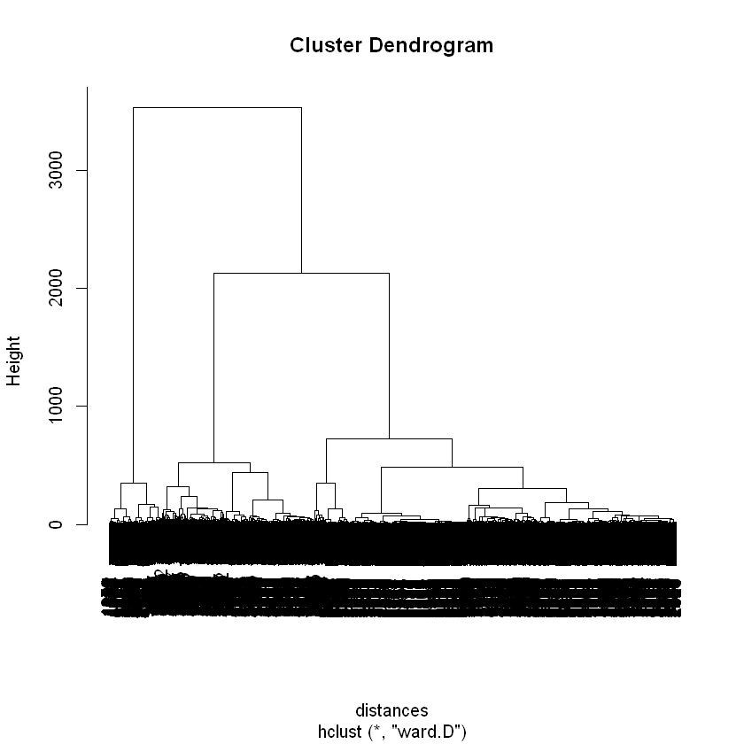

```r
plot(clusterkos)
```

As there arev lots of observations, we see black region at the bottom of the dendogram. Let's assign points to our clusters and create seven clusters.

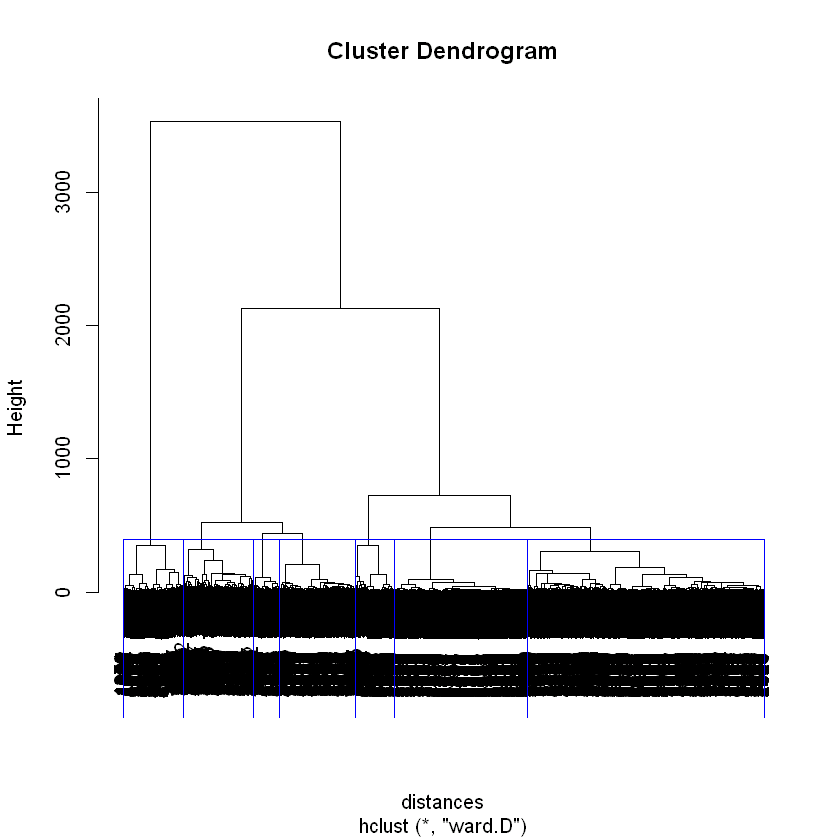

```r
plot(clusterkos)
rect.hclust(clusterkos, k = 7, border = "blue")
```

#### Cluster groups

Now, let's create cluster groups with seven clusters.

```r
clusterGroups = cutree(clusterkos, k = 7)
```

- Number of observations in each group

Now, let's calculate number of observations in each group.

```r
observations=c()
for (i in seq(1,7)){

  observations=c(observations,length(subset(clusterkos, clusterGroups==i)))
}
observations =as.data.frame(list(cluster=c(1:7),Number_of_observations=observations))
observations
```

|  | cluster | Number_of_observations |
| --- | --- | --- |
| 1 | 1 | 1266 |
| 2 | 2 | 321 |
| 3 | 3 | 374 |
| 4 | 4 | 139 |
| 5 | 5 | 407 |
| 6 | 6 | 714 |
| 7 | 7 | 209 |

#### Most frequent words in each cluster

```r
g1<-subset(kos, clusterGroups==1)

tail(sort(colMeans(g1)))
```

[output not shown]

```r
options(jupyter.plot_mimetypes = 'image/png')
options(repr.plot.width = 5)
options(repr.plot.height = 3)
```

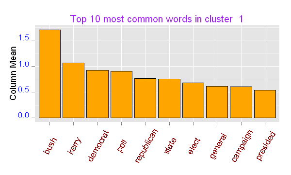

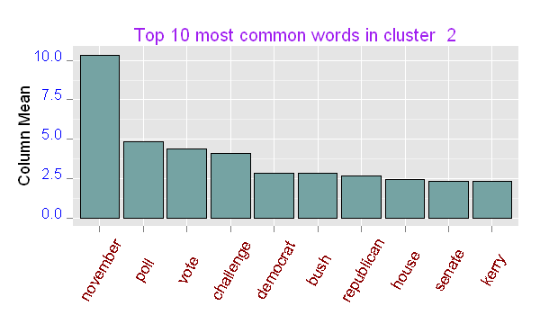

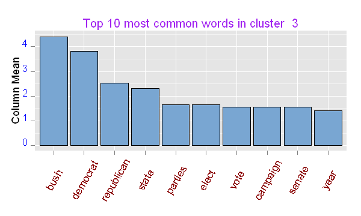

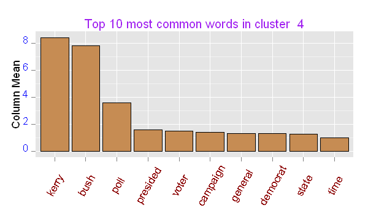

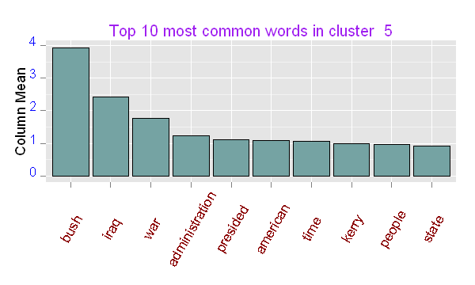

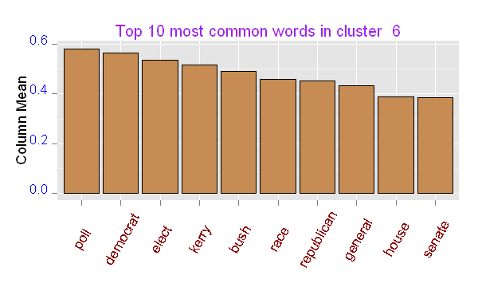

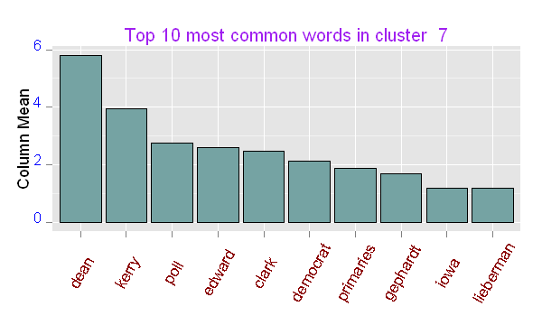

```r
for(i in seq(1,7)){
top10=tail(sort(colMeans(subset(kos,clusterGroups==i))),10)

words=names(top10)
freq=as.vector(top10)

topwords=as.data.frame(list(words=words,freq=freq))

topwords$words <- factor(topwords$words, levels = topwords$words[order(topwords$freq,decreasing =T)])

color=c('#75a3a3','#999966','#79a6d2','#c68c53','orange','skyblue')

fig= ggplot(topwords, aes(words,freq))+ ylab("Column Mean")+
geom_bar(stat='identity',fill=sample(color,1,replace=T),color='black')+
ggtitle(paste('Top 10 most common words in cluster ',i))+
  theme(plot.title = element_text(size = 12,colour="purple"))+
theme(axis.title.x=element_blank(),axis.text.y = element_text(color="blue",size=10,angle=0,hjust=1,vjust=0),
      axis.text.x = element_text(color="darkred",size=10,angle=60,hjust=.5,vjust=.5),
     axis.text.y = element_text(color="red", size=10),
     axis.title.y = element_text(size=11))

print(fig)
}
```

Using the most common words in each cluster, we can infer what each cluster is mainly about. From the figures above, we can see that cluster 5 was mainly about Iraq Invation. The most common words in cluster seven are dean, kerry, poll and edward. Therefore, cluster seven is democratic cluster.

#### K-means clustering

Now, let's use K-means clustering and create seven clusters. Since K-means clustering results depend on the random initilization step, we have to run it many times to get the most stable and accurate K-means clusters. For now, let's set the seed and run K-means clustering just one time.

```r
set.seed(1000)
KMC = kmeans(kos, centers = 7)
names(KMC)
```

1. "cluster"

2. "centers"

3. "totss"

4. "withinss"

5. "tot.withinss"

6. "betweenss"

7. "size"

8. "iter"

9. "ifault"

- Now, let's calculate the number of observations in each cluster

```r
observations=c()
for (i in seq(1,7)){

  observations=c(observations,dim(kos[KMC$cluster==i,])[1])
}
observations =as.data.frame(list(cluster=c(1:7),Number_of_observations=observations))
observations
```

|  | cluster | Number_of_observations |
| --- | --- | --- |
| 1 | 1 | 146 |
| 2 | 2 | 144 |
| 3 | 3 | 277 |
| 4 | 4 | 2063 |
| 5 | 5 | 163 |
| 6 | 6 | 329 |
| 7 | 7 | 308 |

```r
KMC$centers
```

[output not shown]

### Most frequent words in each cluster

Now, let's find the most common words in each cluster as what we did with hierarchical clustering.

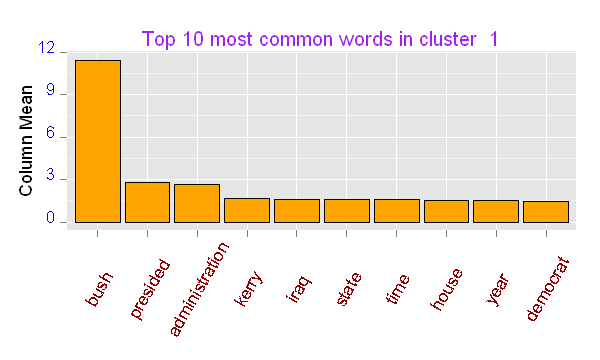

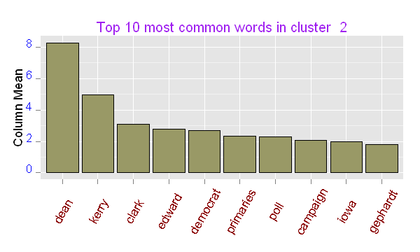

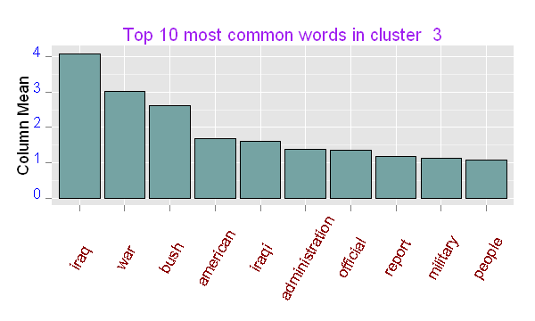

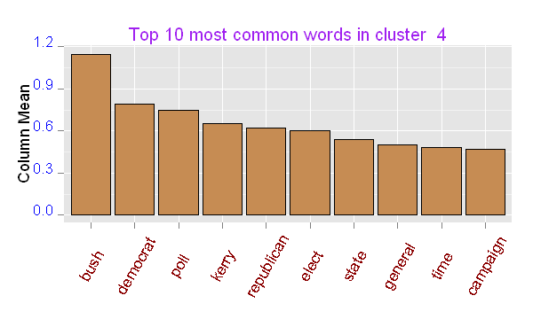

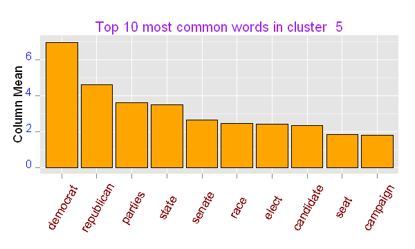

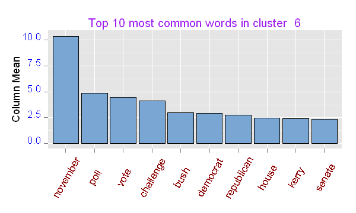

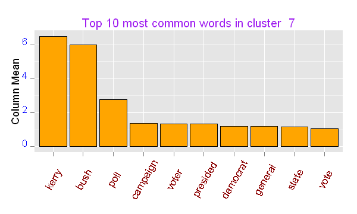

```r
for(i in seq(1,7)){
top10=tail(sort(colMeans(subset(kos, KMC$cluster==i))),10)

words=names(top10)
freq=as.vector(top10)

topwords=as.data.frame(list(words=words,freq=freq))

topwords$words <- factor(topwords$words, levels = topwords$words[order(topwords$freq,decreasing =T)])

color=c('#75a3a3','#999966','#79a6d2','#c68c53','orange','skyblue')

fig= ggplot(topwords, aes(words,freq))+ ylab("Column Mean")+
geom_bar(stat='identity',fill=sample(color,1,replace=T),color='black')+
ggtitle(paste('Top 10 most common words in cluster ',i))+
  theme(plot.title = element_text(size = 12,colour="purple"))+
theme(axis.title.x=element_blank(),axis.text.y = element_text(color="blue",size=10,angle=0,hjust=1,vjust=0),
      axis.text.x = element_text(color="darkred",size=10,angle=60,hjust=.5,vjust=.5),
     axis.text.y = element_text(color="red", size=10),
     axis.title.y = element_text(size=11))

print(fig)
}
```

#### Comapring K-means with hierarchical clustering

Now, let's compare how observations were assigned to clusters in the two methods.

```r
kmeans_clusters=KMC$cluster
table(clusterGroups,kmeans_clusters)
```

```
             kmeans_clusters
clusterGroups    1    2    3    4    5    6    7
            1    3   11   64 1045   32    0  111
            2    0    0    0    0    0  320    1
            3   85   10   42   79  126    8   24
            4   10    5    0    0    1    0  123
            5   48    0  171  145    3    1   39
            6    0    2    0  712    0    0    0
            7    0  116    0   82    1    0   10
```

### Let's change them to ratios in percentages

```r
kmeans_clusters=KMC$cluster

my.table <- table(clusterGroups,kmeans_clusters)

my.prop <- round(prop.table(my.table,2),3)*100
my.prop
```

```
             kmeans_clusters
clusterGroups    1    2    3    4    5    6    7
            1  2.1  7.6 23.1 50.7 19.6  0.0 36.0
            2  0.0  0.0  0.0  0.0  0.0 97.3  0.3
            3 58.2  6.9 15.2  3.8 77.3  2.4  7.8
            4  6.8  3.5  0.0  0.0  0.6  0.0 39.9
            5 32.9  0.0 61.7  7.0  1.8  0.3 12.7
            6  0.0  1.4  0.0 34.5  0.0  0.0  0.0
            7  0.0 80.6  0.0  4.0  0.6  0.0  3.2
```

- K-means cluster two corresponds to cluster seven in hierarchical clustering
- K-means cluster three corresponds to cluster five in hierarchical clustering
- No cluster from hierarchical clustering contains more than 50% of cluter seven from K-means
- K-means cluster six corresponds to cluster two in hierarchical clustering

#### Summary

In this post, we saw how to use K-means and hierarchical clustering for text clustering, which is also called document clustering. We infered what each cluster is mainly about using the most common words in each cluster. Since K-means clustering is affected by the random initializations, reapting it many times is important to get more stable and accurate clusters.